# Détection d’anomalies

Authors

Yanis Micha

Andrew Hardwick

[Lien vers notre git](https://github.com/yanismicha/Apprentissage_stat). Vous retrouverez l’ensemble des projets de cet UE sur ce git.

Vous trouverez en haut à droite un interrupteur permettant de passer le rendu en mode sombre/jour à activer selon votre préférence.

Ce rapport cherche à évaluer diverses méthodes de détection d’anomalies, sur un jeu de donnée comportent 6916 observations et 21 dimensions. Il comporte 6666 observations normales et 250 outliers.

# 1 Présentation des données

Comme on peut le voir dans la Figure 1 qui présente les variables continues, aucune de ces variables ne permet de séparer proprement les outliers.

**Voir le code**

```r
GGally::ggpairs(data.frame(X[,c(1,17:21)]), aes(color=y))
```

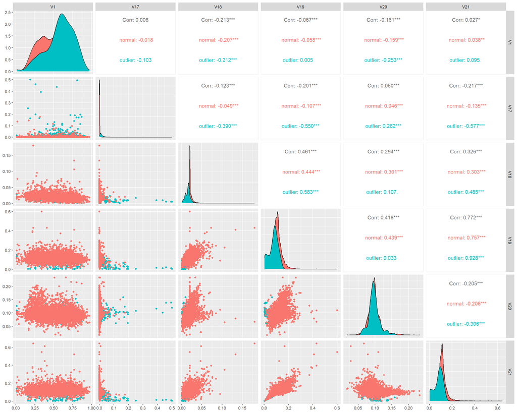

Figure 1: Relation entre les variables continue.

# 2 Comparatif courbes roc

## 2.1 Local Outlier Factor

Nous avons en premier lieu testé l’efficacité de l’algorithme `Local Outlier Factor` pour la détection des anomalies dans notre jeu de donné.

L’algorithme consiste pour chaque observation a calculer sa distance avec ces k plus proche voisins. On compare ensuite la moyenne de ces distances, à la moyenne des distances des k voisins initiaux avec chacun de leur k plus proche voisin. Ceci nous permet de calculer un score pour chaque observation qui représente le ratio entre ces 2 distances.

**Voir le code**

```r
best_acc <- 0
best_k <- 0
for(k in 2:15){
  lof <- lof(X, minPts = k)
  pred <- ifelse(lof==Inf,"outlier","normal")
  acc <- sum(pred == data$cat) / length(data$cat)
  if(acc > best_acc){
    best_acc <- acc
    best_k <- k
  }
}


lof <- lof(X,minPts = best_k)
predicted <- ifelse(lof>= 2,"outlier","normal")
score<- accuracy(predicted,data$cat)
#print(paste0("Accuracy: ", score, ", k: ",best_k))
```

Après sélection de la meilleur taille de voisinage k, le meilleur modèle semble être k=7 qui retourne une accuracy de 0.927.

## 2.2 Isolation Forest

Nous avons ensuite testé la méthode de `l'Isolation Forest`. Cette méthode sépare aléatoirement le jeu de donné en 2 sur une dimension aléatoire. Il répète ce processus pour chaque sous-jeu de donnée jusqu’à isoler une observation. Cette observation devient une feuille de l’arbre et tout le reste du jeu de données devient un nœud. Ce processus peut être répété jusqu’à l’isolation de tous les individus, ou jusqu’à atteindre une profondeur spécifiée. Toutes les feuilles de l’arbre binaire qui en ressort sont donc des observations isolées. Les feuilles en haut de l’arbre sont celles qui ont nécessités le moins de séparations pour être isolé, ont donc plus de chance d’être des outliers. Plusieurs arbres de ce type sont construits et les observations qui se retrouvent le plus souvent en haut des arbres sont ceux qui sont désignés comme outliers.

Bien qu’un grand nombre de paramètres existe, comme pour le random forest nous avons ici uniquement testé le nombre d’arbres construit et la distribution du découpage aléatoire.

**Voir le code**

```r
best_acc <- 0
best_ntrees <- 0
best_coef <- NULL
for(co in c("uniform","normal")){
  for(n in seq(10,200,10)){
    iso <- isolation.forest(X,ntrees = n, coefs = co)
    pred <- predict(iso,X)
    # on affiche comme outlier les 5%de valeurs les plus hautes
    predicted <- ifelse(pred>quantile(pred, probs = 0.95),"outlier","normal")
    score_iso <- accuracy(predicted,y)
    if(score_iso > best_acc){
      best_acc <- score_iso
      best_ntrees <- n
      best_coef <- co
    }
  }
}
iso <- isolation.forest(X,ntrees = best_ntrees)
pred <- predict(iso,X)
predicted <- ifelse(pred>quantile(pred, probs = 0.95),"outlier","normal")
score_iso <- accuracy(predicted,y)
```

## 2.3 One-Class Support vector Machine

Le modèle `SVM` cherche à trouver un hyperplan qui sépare les observations en classes de manière optimale, i.e en maximisant la marge entre les classes et ce dernier, ce tout en minimisant l’erreur de classification. Contrairement au SVM traditionnel qui est une méthode d’apprentissage supervisé, sa variante `One-class SVM` est une méthode non supervisée permettant la détéction d’anomalies. Il n’apprend qu’à partir d’une seule classe, celle qui est la plus représentative ou normale dans les données, et modélise la région d’acceptation qui contient la majorité des données.  
Nous avons utilisé cette méthode One-class SVM en cherchent les meilleurs paramètres.

**Voir le code**

```r
best_params_auc <- c()
best_auc <- 0
best_acc <- 0
best_params <- c()
for(gamma in seq(0,1,0.1)){
  for(kernel in c("polynomial","linear","radial","sigmoid")){
    for(nu in c(0.01,0.05,0.1,0.15,0.2)){
      svm <- svm(X,type='one-classification',nu=nu, kernel=kernel,gamma=gamma)
      pred_svm <- ifelse(predict(svm,X),"normal","outlier")
      auc_svm <- auc(roc(y,svm$decision.values[,1]))
      if(auc_svm>best_auc){
        best_auc <- auc_svm
        best_params_auc<- c("gamma" = gamma,"kernel" = kernel, "nu" = nu)
      }
      if(accuracy(y,pred_svm)>best_acc){
        best_acc <- accuracy(y,pred_svm)
        best_params <- c("gamma" = gamma,"kernel" = kernel, "nu" = nu)
      }
    }
  }
}
svm <- svm(X,type="one-classification",nu=best_params["nu"],kernel=best_params["kernel"],gamma=best_params["gamma"])
pred_svm <- predict(svm,X)
pred_svm <- ifelse(pred_svm,"normal","outlier")
tab <- caret::confusionMatrix(table(pred_svm,y))
roc_svm <- roc(y,svm$decision.values[,1])
```

Les meilleurs paramètres pour le SVM semblent être kernel = sigmoid, nu = 0.01, gamma = 0.4. Avec ces paramètres, le modèle donne une accuracy de 0.957.

## 2.4 Gaussienne multivariée

Le modèle Gaussien cherche à ajuster un modèle Gaussien multivarié sur l’ensemble des variables en estiment les paramètres en maximisant la vraisemblance.

Pour permettre un meilleur fonctionnement du modèle, il sera ajusté uniquement sur les données continues.

**Voir le code**

```r
gaus = mclust::Mclust(X[,-c(2:16)], G=2)
gaus_pred = predict(gaus)
gaus_acc = sum(ifelse(gaus_pred$classification == 1, "normal", "outlier") == data$cat) / length(data$cat)
roc_gaus = roc(data$cat,gaus_pred$z[,1])
```

## 2.5 Comparaison des 4 méthodes

**Voir le code**

```r
# on créer un objet roc
roc_lof <- roc(y,-lof)
roc_iso <- roc(y, -pred)
# trace les courbes roc
ggroc(list(LOF = roc_lof, IsolationForest = roc_iso, gaussienne = roc_gaus, SVM = roc_svm))+
  annotate(geom="text",x = 0.3,y = 0.4,label = paste0("LOF: AUC=",round(auc(roc_lof),2),", ACCURACY=",round(score,2)))+
  annotate(geom="text",x = 0.3,y = 0.35,label = paste0("ISO: AUC=",round(auc(roc_iso),2),", ACCURACY=",round(score_iso,2)))+
  annotate(geom="text",x = 0.3,y = 0.3,label = paste0("Gauss: AUC=",round(auc(roc_gaus),2),", ACCURACY=",round(gaus_acc,2)))+
  annotate(geom="text",x = 0.3,y = 0.25,label = paste0("SVM: AUC=",round(auc(roc_svm),2),", ACCURACY=",round(tab$overall[1],2)))+
  ggtitle("Courbe ROC des 4 modèles")
```

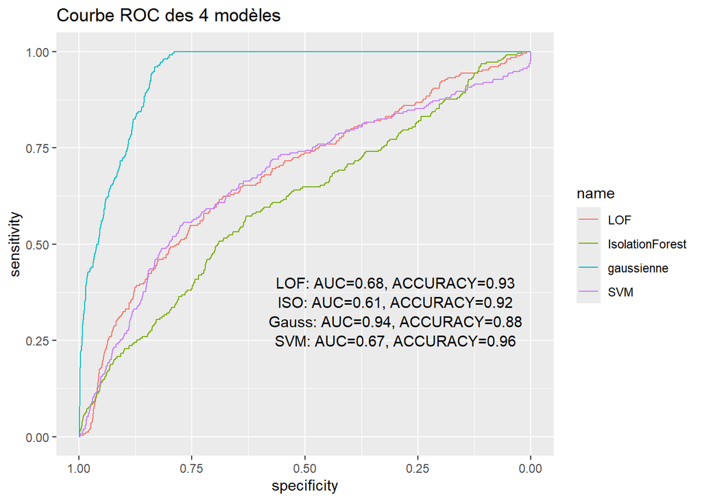

# 3 Avec standardisation des variables et ACP

Une ACP a été effectuée sur les données standardisées pour voir si cela permet de mieux séparer les outliers.

On peut voir dans la Figure 3 que les résultats de l’ACP semble avoir un peu mieux séparé les outliers que dans les données de base présenté dans la Figure 1.

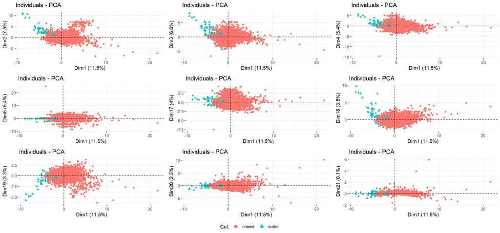

Figure 3: Résultat d’une ACP sur les données.

Nous allons donc retenter les 4 méthodes sur les dimensions retourné par l’ACP.

## 3.1 LOF

**LOF sur ACP**

```r
best_acc <- 0
best_k <- 0
for(k in 2:15){
  lof <- lof(X_pca, minPts = k)
  pred <- ifelse(lof==Inf,"outlier","normal")
  acc <- sum(pred == data$cat) / length(data$cat)
  if(acc > best_acc){
    best_acc <- acc
    best_k <- k
  }
}


lof_pca <- lof(X_pca,minPts = best_k)
predicted <- ifelse(lof_pca>= 2,"outlier","normal")
score_lof_pca<- accuracy(predicted,data$cat)
score_lof_pca
```

```
[1] 0.9451995
```

On peut voir dans la Figure 4 que la projection des données avec à l’ACP a permit d’améliorer la performance du Local Outlier Factor.

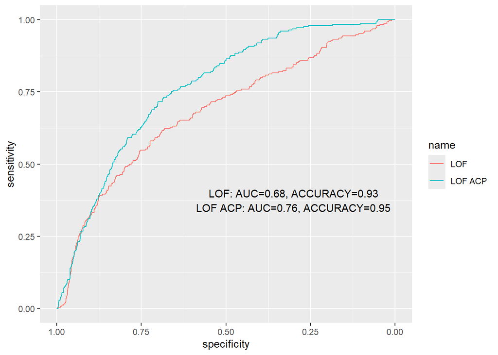

Figure 4: Comparaison des courbes ROC pour les modèles Local Outlier Factor avec et sens ACP

## 3.2 Isolation Forest

La Figure 5 montre que la projection des données avec à l’ACP n’a pas permis l’amélioration des performances de l’Isolation Forest.

**Isolation Forest sur ACP**

```r
best_acc <- 0
best_ntrees <- 0
best_coef <- NULL
for(co in c("uniform","normal")){
  for(n in seq(10,200,10)){
    iso <- isolation.forest(X_pca,ntrees = n, coefs = co)
    pred <- predict(iso,X)
    # on affiche comme outlier les 5%de valeurs les plus hautes
    predicted <- ifelse(pred>quantile(pred, probs = 0.95),"outlier","normal")
    score_iso <- accuracy(predicted,y)
    if(score_iso > best_acc){
      best_acc <- score_iso
      best_ntrees <- n
      best_coef <- co
    }
  }
}
model_forest <- isolation.forest(X_pca,ntrees = best_ntrees, coefs = best_coef)
pred <- predict(model_forest,X_pca)
predicted <- ifelse(pred>quantile(pred, probs = 0.95),"outlier","normal")
score_iso_pca <- accuracy(predicted,y)
```

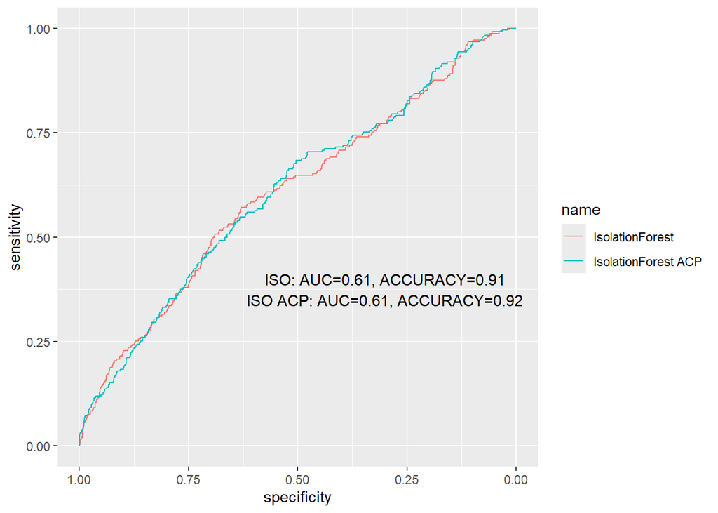

Figure 5: Comparaison des courbes ROC pour les modèles IsolationForest avec et sans ACP

## 3.3 One-Class SVM

**One-Class SVM sur ACP**

```r
best_params_auc <- c()
best_auc <- 0
best_acc <- 0
best_params <- c()
for(gamma in seq(0,1,0.1)){
  for(kernel in c("polynomial","linear","radial","sigmoid")){
    for(nu in c(0.01,0.05,0.1,0.15,0.2)){
      svm_pca <- svm(X_pca,type='one-classification',nu=nu, kernel=kernel,gamma=gamma)
      pred_svm <- ifelse(predict(svm_pca,X_pca),"normal","outlier")
      if(length(table(pred_svm)) > 1 & accuracy(y,pred_svm)>best_acc){
        best_acc <- accuracy(y,pred_svm)
        best_params <- c("gamma" = gamma,"kernel" = kernel, "nu" = nu)
      }
    }
  }
}
svm_pca = svm(X_pca,type='one-classification',nu=best_params["nu"], kernel=best_params["kernel"],gamma=best_params["gamma"])
pred_svm_pca <- predict(svm_pca,X_pca)
pred_svm_pca <- ifelse(pred_svm_pca,"normal","outlier")
tab_svm_pca <- caret::confusionMatrix(table(pred_svm_pca,y))
```

Les meilleurs paramètres pour les données de l’ACP semblent être kernel = sigmoid, nu = 0.01, gamma = 0.4. Avec ces paramètres, le modèle donne une accuracy de 0.956. On remarquera que ce sont les mêmes paramètres que le meilleur modèle pour les données originales.

Bien que l’utilisation de l’ACP a permis d’augmenter l’AUC du SVM, il ne semble pas avoir eu d’effet sur son accuracy (Figure 6).

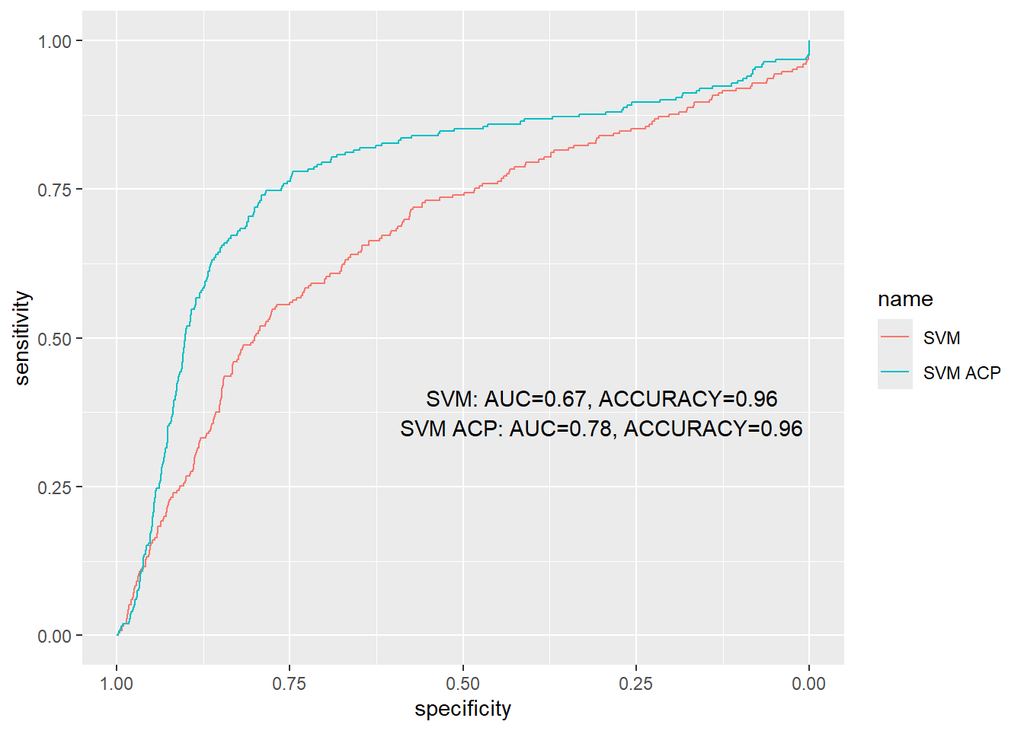

Figure 6: Comparaison des courbes ROC pour les modèles SVM avec et sans ACP

## 3.4 Gaussienne multivariée

**Gaussienne multivariée sur ACP**

```r
gaus_pca = mclust::Mclust(X_pca, G=2)
gaus_pred_pca = predict(gaus_pca)
gaus_acc_pca = sum(ifelse(gaus_pred_pca$classification == 1, "normal", "outlier") == data$cat) / length(data$cat)
roc_gaus_pca = roc(data$cat,gaus_pred_pca$z[,1])
```

Comme le montre la Figure 7 l’utilisation de l’ACP semble avoir grandement réduit l’accuracy et l’AUC du modèle Gaussien.

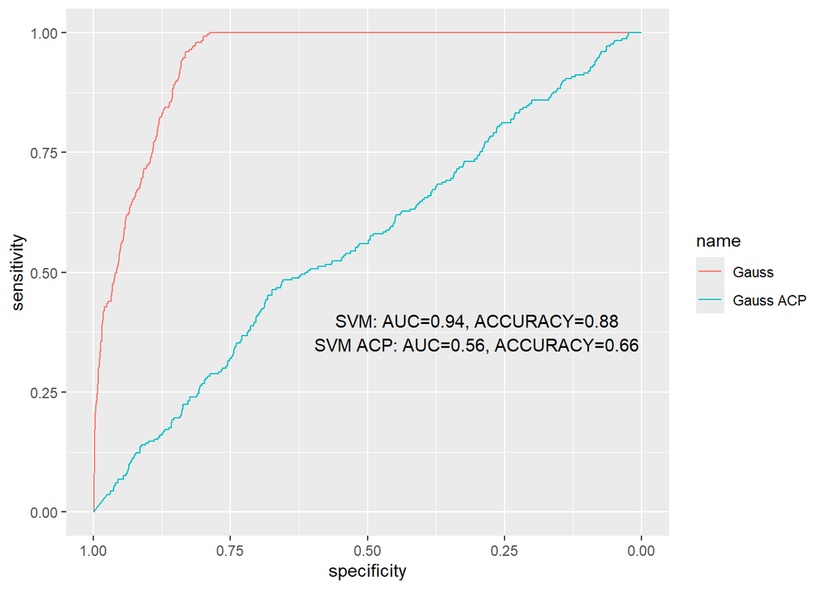

Figure 7: Comparaison des courbes ROC pour les modèles Gaussienne multivariée avec et sens ACP

## 3.5 Comparaison des 4 méthodes avec ACP

**Voir le code**

```r
# on créer un objet roc
roc_lof_acp <- roc(y,-lof_pca)
roc_iso_acp <- roc(y, -pred)
roc_svm_pca <- roc(y,svm_pca$decision.values[,1])
roc_gaus_pca <- roc(data$cat,gaus_pred_pca$z[,2])
# trace les courbes roc
ggroc(list(LOF=roc_lof_acp,IsolationForest=roc_iso_acp, SVM = roc_svm_pca, Gaussian = roc_gaus_pca))+
  annotate(geom="text",x = 0.7,y = 0.9,label = paste0("LOF: AUC=",round(auc(roc_lof_acp),2),", ACCURACY=",round(score_lof_pca,2)))+
  annotate(geom="text",x = 0.7,y = 0.8,label = paste0("ISO: AUC=",round(auc(roc_iso_acp),2),", ACCURACY=",round(score_iso_pca,2)))+
  annotate(geom="text",x = 0.7,y = 0.8,label = paste0("SVM: AUC=",round(auc(roc_svm_pca),2),", ACCURACY=",round(tab_svm_pca$overall[1],2)))+
  annotate(geom="text",x = 0.7,y = 0.8,label = paste0("Gauss: AUC=",round(auc(roc_gaus_pca),2),", ACCURACY=",round(gaus_acc_pca,2)))+
  ggtitle("Courbes ROC des modèles sur ACP normalisé")
```

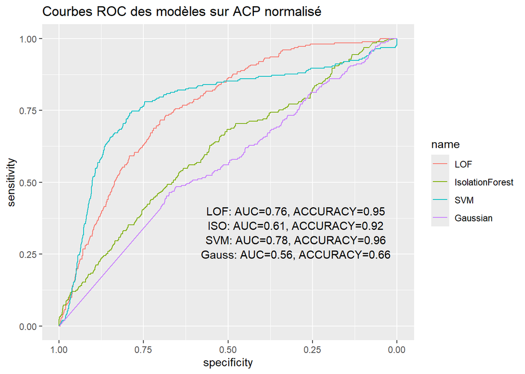

Figure 8: Comparaison des courbes ROC pour les 4 modèles avec l’ACP.

Table 1: Comparaison des résultats.

|  | LOF | ISO | SVM | Gaussien |
| --- | --- | --- | --- | --- |
| AUC sans ACP | 0.682 | 0.608 | 0.674 | 0.941 |
| AUC avec ACP | 0.763 | 0.611 | 0.776 | 0.559 |
| Accuracy sans ACP | 0.927 | 0.915 | 0.957 | 0.881 |
| Accuracy avec ACP | 0.945 | 0.922 | 0.956 | 0.660 |

En regardant la Figure 8 et la Table 1, on peut voir que l’utilisation de l’ACP semble avoir globalement augmenté les performances du Local Outlier Factor et légèrement celle de l’Isolation Forest. Pour le SVM, bien que l’utilisation de ACP augmente l’AUC, il diminue très faiblement l’accuracy. Pour finir, on peut voir que l’utilisation de l’ACP diminue fortement la performance du modèle Gaussien.

# 4 Comparaison des meilleurs modèles

Du fait du grand déséquilibre entre les classes, la sélection du meilleur modèle s’est faite sur le critère de l’AUC.

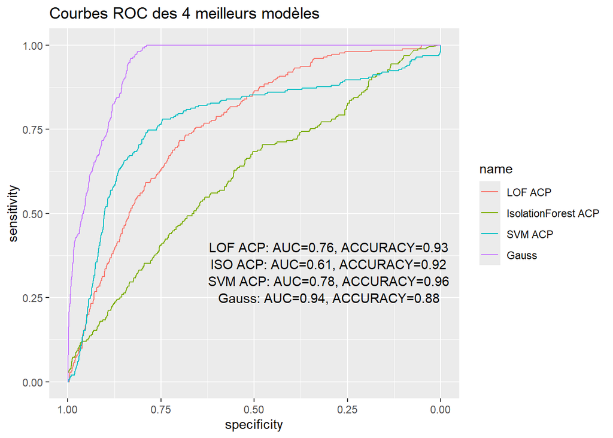

Figure 9: Comparaison des courbes ROC de tous les meilleurs modèles.